# Predicción del precio de viviendas en la RM

## Integrantes:

Cristobal Ardiles, Simon Lourido, Cristian Carrión, Roberto Maldonado, Asunción Gómez

# HITO 1

# Introducción

Actualmente la Región Metropolitana experimenta un alza en los precios de las viviendas donde la ciudad de Santiago, a septiembre del año pasado, era la urbe latinoamericana con mayor alza en los valores de las viviendas. Este es un tema que afecta a la gran mayoría de la población y genera la interrogante del porqué de estos precios. Los datos sobre precio y características de viviendas en venta son abundantes y existe la intención de comparar datos del año 2020, el cual marca el inicio de la pandemia, con datos actuales del año 2022. Junto a esto se busca encontrar la influencia de factores externos sobre el precio de las viviendas, tales como, nivel de delincuencia.

El objetivo de este estudio de datos es llegar a un mayor entendimiento sobre la forma en que distintas variables afectan al precio de las viviendas, específicamente de casas. Para así poder determinar las más variables relevantes y, si es posible, generar una predicción del precio de las casas en función de estas. Para esto se utilizará principalmente un data set sobre avisos de casas usadas en venta en la Región Metropolitana en Mayo del 2020. Para complementar, se obtuvo utilizando webscraping, un data set actualizado del original, con avisos de la primera semana de Abril del 2022. El factor externo que se considerará será la delincuencia en el sector donde se ubica la vivienda, por lo que tambien se estudiará un data set del gobierno sobre niveles de delincuencia por comuna.

Resulta interesante realizar un estudio sobre las viviendas de la región, ya que existen muchos factores que pueden afectar su precio. Más allá de los factores principales que afectan directamente el precio de una vivienda, tales como el tamaño de la casa, del jardín, número de habitaciones, número de baños, etc, existen factores externos relacionados a la ubicación que pueden tener relevancia. De estos el más relevante es la delincuencia, en la actualidad, uno se ve expuesto a ser víctima de asalto, acoso, e incluso secuestro, situaciones las cuales uno observa en aumento día a día como estudiante. Ese sentimiento de inseguridad afecta la calidad de vida de las personas y por lo que es importante considerar este factor al momento de comprar una vivienda. Pero ¿que tanto afectan estos factores al momento de evaluar el precio de una casa? En este proyecto se busca dar respuesta a esta interrogante y generar un modelo predictivo basado en estos factores, para determinar el precio estimado de una vivienda en la Región Metropolitana.

# Exploración

Para estudiar el problema planteado, se obtuvo el dataset [*Casas Usadas - RM Mayo 2020*](https://www.kaggle.com/gorkigonzalez/casas-usadas-rm-chile-mayo-2020?select=Casas+usadas+-+RM+Mayo+2020.csv). Este dataset nos entrega información sobre las casas publicadas en el portal [ChilePropiedades](https://chilepropiedades.cl/) a mayo del 2020.

```python
#import libraries
import numpy as np
import pandas as pd
import seaborn as sns
from matplotlib import pyplot as plt
print("Librerias cargadas")
```

```
Librerias cargadas
```

## Data set Propiedades 2020

```python
#Carga dataset
url_raw_prop_2020 = 'https://raw.githubusercontent.com/ccarrions/Data_Mining_Project/main/dataset_chile_prop_2020.csv'
# dataframe sector
df_prop_2020 = pd.read_csv(url_raw_prop_2020, sep=";", encoding= "latin1")
df_prop_2020.head(3)
```

|  | Comuna | Link | Tipo_Vivienda | N_Habitaciones | N_Baños | N_Estacionamientos | Total_Superficie_M2 | Superficie_Construida_M2 | Valor_UF | Valor_CLP | Dirección | Quién_Vende | Corredor |
| --- | --- | --- | --- | --- | --- | --- | --- | --- | --- | --- | --- | --- | --- |
| 0 | Calera de Tango | https://chilepropiedades.cl/ver-publicacion/ve... | Casa | 5.0 | 6.0 | 3 | 5000 | 440 | 12.2 | 351360000 | Calera de Tango, Queilen | Gabriela Mellado V. | Zenpro Propiedades |
| 1 | Calera de Tango | https://chilepropiedades.cl/ver-publicacion/ve... | Casa | 6.0 | 6.0 | 6 | 5000 | 430 | 13.0 | 374400000 | Calera de Tango, Queilen | Gabriela Mellado V. | Zenpro Propiedades |
| 2 | Calera de Tango | https://chilepropiedades.cl/ver-publicacion/ve... | Casa | 3.0 | 3.0 | No | 2027 | 140 | 10.3 | 296640000 | Calera de Tango, Avenida calera de tango con... | Alonso Baeza Rivera y Cía. Ltda. (Kennedy) | Alonso Baeza Rivera y Cía. Ltda. (Kennedy) |

### Transformar datos a númerico

Se procede a transformar del tipo de variables de las columnas "Total_Superficie_M2", "Superficie_Construida_M2" y "N_Estacionamientos", desde "string" a "entero".

```python
df_prop_2020["Total_Superficie_M2"] = df_prop_2020["Total_Superficie_M2"].str.replace(",",".")
df_prop_2020["Total_Superficie_M2"] = pd.to_numeric(df_prop_2020["Total_Superficie_M2"])
```

```python
df_prop_2020["Superficie_Construida_M2"] = df_prop_2020["Superficie_Construida_M2"].str.replace(",",".")
df_prop_2020["Superficie_Construida_M2"] = df_prop_2020["Superficie_Construida_M2"].str.replace(" ha","0000")
df_prop_2020["Superficie_Construida_M2"] = pd.to_numeric(df_prop_2020["Superficie_Construida_M2"])
```

```python
df_prop_2020["N_Estacionamientos"] = df_prop_2020["N_Estacionamientos"].str.replace("No","0")
df_prop_2020["N_Estacionamientos"] = pd.to_numeric(df_prop_2020["N_Estacionamientos"])
```

```python
df_prop_2020.rename(columns={' Valor_UF ': 'Valor_UF'}, inplace=True)
df_prop_2020["Valor_UF"] = df_prop_2020["Valor_UF"]*1000
```

### Medidas Tendencia Central

```python
meanData = df_prop_2020.mean(numeric_only=True)
print("Promedio de columnas numéricas")
print(meanData)
```

```
Promedio de columnas numéricas
N_Habitaciones              4.109637e+00
N_Baños                     2.652952e+00
N_Estacionamientos          1.113402e+00
Total_Superficie_M2         8.660973e+02
Superficie_Construida_M2    1.983199e+03
Valor_UF                    1.021802e+04
Valor_CLP                   2.942870e+08
dtype: float64
```

Se puede ver un promedio esperado en N_Habitaciones, N_Baños y N_estacionamientos. En cuanto al promedio de Valor_UF, Valor_CLP Total_Superficie_M2 y Superficie_Construidas, son valores más alto de los esperados que se pueden ver influidos por outliers.

```python
medianData = df_prop_2020.median(numeric_only=True)
print("Mediana de columnas numéricas")
print(medianData)
```

```
Mediana de columnas numéricas
N_Habitaciones                      4.0
N_Baños                             2.0
N_Estacionamientos                  0.0
Total_Superficie_M2               293.0
Superficie_Construida_M2          140.0
Valor_UF                         6700.0
Valor_CLP                   192960000.0
dtype: float64
```

Tanto N_habitaciones como N_baños coinciden con los valores obtenidos en la tabla promedio. En cambio Total_Superficie_M2, Superficie_Construida_M2, Valor_UF y Valor_CLP, son valores más bajos que los que mostraba el promedio y esto se puede explicar dado que la mediana es una medida más robusta a outliers.

```python
modeData = df_prop_2020.mode(numeric_only=True)
print("Moda de columnas numéricas")
print(modeData)
```

```
Moda de columnas numéricas
   N_Habitaciones  N_Baños  N_Estacionamientos  Total_Superficie_M2  \
0             3.0      2.0                 0.0               5000.0

   Superficie_Construida_M2  Valor_UF  Valor_CLP
0                     140.0    2951.0   85000000
```

Se puede ver que el valor de la moda de Total_Superficie_M2 es particularmente alta.

### Medidas Multivarianza

```
Covarianza
```

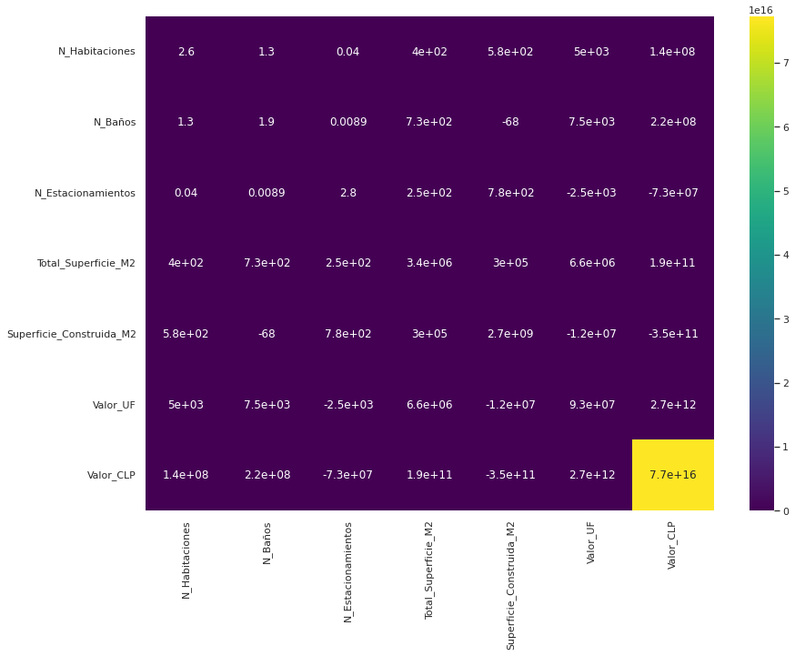

```python
covData = df_prop_2020.cov()
print("Covarianza")
sns.set(style="darkgrid")
# heatmap covarianza
plt.figure(figsize=(14, 10))
sns.heatmap(df_prop_2020.cov(), cmap='viridis', annot=True);
```

```
Correlación
```

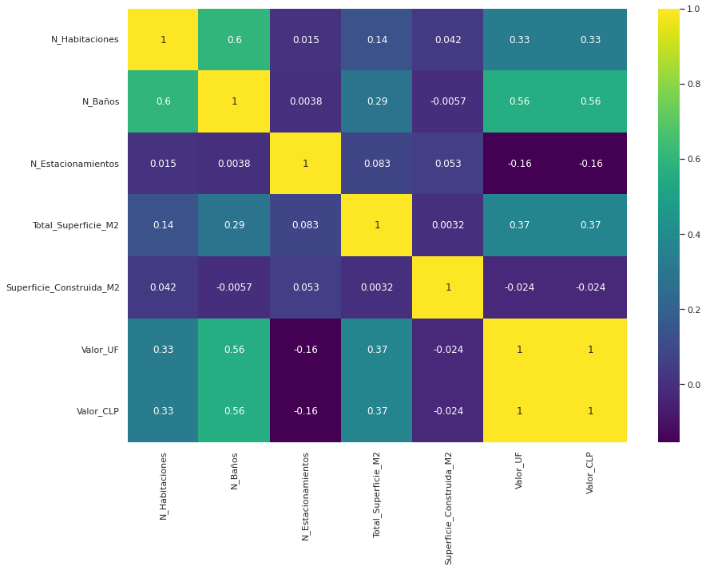

```python
corrData = df_prop_2020.corr()
print("Correlación")
# print(corrData)
sns.set(style="darkgrid")
# heatmap covarianza
plt.figure(figsize=(14, 10))
sns.heatmap(df_prop_2020.corr(), cmap='viridis', annot=True);
```

Lógicamente, Valor_UF y Valor_CLP están perfectamente correlacionadas dado que son 2 formas de medir el mismo valor. Además se puede ver un valor alto de correlación entre N_Habitaciones y N_Baños lo cual es entendible.

Por otro lado se puede apreciar que el N_Baños es la variable que tiene más correlación con el precio de las viviendas.

### Gráficos

Se realiza del boxplot de las columnas de N_Baños y Valor_UF, ya qué podría resultar interesante dado su alta correlación.

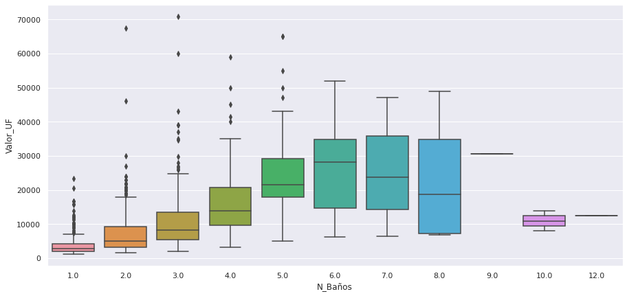

```python
plt.figure(figsize=(15,7))

# Define figure size
sns.set(rc={"figure.figsize":(15, 8)}) #width, height

# Give it to the boxplot
sns.boxplot(x='N_Baños', y='Valor_UF', data = df_prop_2020)
plt.show();
```

Se realiza también un boxplot entre N_Habitaciones y el precio(Valor_UF), para ver como se comporta la relación entre estas 2.

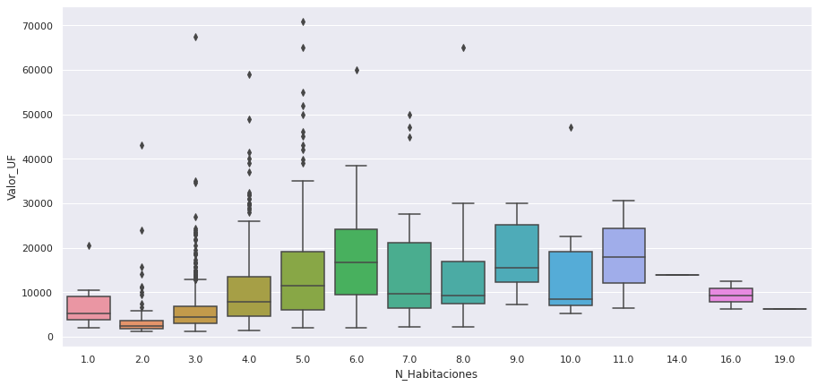

```python
plt.figure(figsize=(15,7))

# Define figure size
sns.set(rc={"figure.figsize":(15, 8)}) #width, height

# Give it to the boxplot
sns.boxplot(x='N_Habitaciones', y='Valor_UF', data = df_prop_2020)
plt.show();
```

Se realiza un scatterplot entre Superficie_Construida_M2 y el precio(Valor_UF), para ver como se comporta la relación entre estas dos variables. Además, se incorpora una tercera variable, la de N_Baños dado su alta correlación con el precio, de forma categórica para mostrar también como se comporta el valor de Superficie_Construida_M2 con el N_Baños.

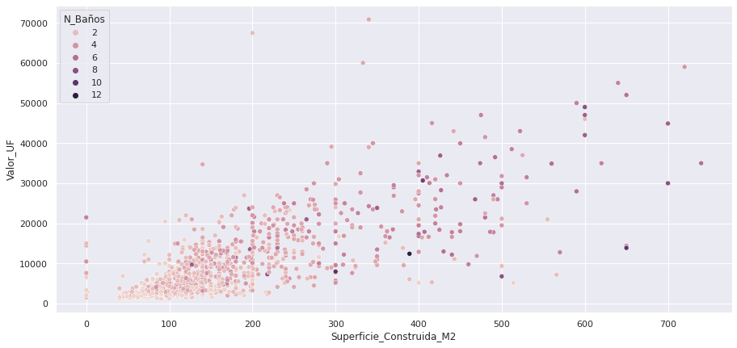

```python
plt.figure(figsize=(15,7))

# Define figure size
sns.set(rc={"figure.figsize":(15, 8)}) #width, height

# Give it to the boxplot
sns.scatterplot(x='Superficie_Construida_M2', y='Valor_UF', hue='N_Baños', data = df_prop_2020[df_prop_2020["Superficie_Construida_M2"]<750])
plt.show();
```

## Cruce con data set Delincuencia 2020

Se fusiona el dataset de viviendas 2020 con el dataset de delincuencia correspondiente a la fecha, según la comuna de cada tupla del primer dataset. Se selecciona solo dos columnas del dataset, por lo que en consecuencia se agrega las columnas de 'Tasa cada 100Mil' y 'Rango', a las tablas de vivienda.

```python
#Carga dataset
url_raw_delincuencia_2020 = 'https://raw.githubusercontent.com/ccarrions/Data_Mining_Project/main/Delincuencia2020.csv'
# dataframe sector
df_delincuencia_2020 = pd.read_csv(url_raw_delincuencia_2020, sep=";", encoding= "utf-8")
df_delincuencia_2020.head(3)
```

|  | Tipo de Información | Comuna | Frecuencia | Tasa cada 100Mil | Rango |
| --- | --- | --- | --- | --- | --- |
| 0 | Casos Policiales | Alhué | 20 | 270,1 | bajo |
| 1 | Casos Policiales | Buin | 456 | 415,9 | medio |
| 2 | Casos Policiales | Calera de Tango | 111 | 389,1 | medio |

```python
df_delincuencia_2020_filter = df_delincuencia_2020[['Comuna', 'Tasa cada 100Mil', 'Rango']]
df_prop_delincuencia_2020 = pd.merge(df_prop_2020,df_delincuencia_2020_filter, on='Comuna',how='left')
df_prop_delincuencia_2020.head(3)
```

|  | Comuna | Link | Tipo_Vivienda | N_Habitaciones | N_Baños | N_Estacionamientos | Total_Superficie_M2 | Superficie_Construida_M2 | Valor_UF | Valor_CLP | Dirección | Quién_Vende | Corredor | Tasa cada 100Mil | Rango |
| --- | --- | --- | --- | --- | --- | --- | --- | --- | --- | --- | --- | --- | --- | --- | --- |
| 0 | Calera de Tango | https://chilepropiedades.cl/ver-publicacion/ve... | Casa | 5.0 | 6.0 | 3.0 | 5000.0 | 440.0 | 12200.0 | 351360000 | Calera de Tango, Queilen | Gabriela Mellado V. | Zenpro Propiedades | 389,1 | medio |
| 1 | Calera de Tango | https://chilepropiedades.cl/ver-publicacion/ve... | Casa | 6.0 | 6.0 | 6.0 | 5000.0 | 430.0 | 13000.0 | 374400000 | Calera de Tango, Queilen | Gabriela Mellado V. | Zenpro Propiedades | 389,1 | medio |
| 2 | Calera de Tango | https://chilepropiedades.cl/ver-publicacion/ve... | Casa | 3.0 | 3.0 | 0.0 | 2027.0 | 140.0 | 10300.0 | 296640000 | Calera de Tango, Avenida calera de tango con... | Alonso Baeza Rivera y Cía. Ltda. (Kennedy) | Alonso Baeza Rivera y Cía. Ltda. (Kennedy) | 389,1 | medio |

#### Transformar datos a númerico

Se transforma el tipo de variable de 'Tasa cada 100mil' de String a Entero.

```python
df_prop_delincuencia_2020["Tasa cada 100Mil"] = df_prop_delincuencia_2020["Tasa cada 100Mil"].str.replace(",",".")
df_prop_delincuencia_2020["Tasa cada 100Mil"] = pd.to_numeric(df_prop_delincuencia_2020["Tasa cada 100Mil"])
```

### Correlación

Con las nuevas columnas incorporadas, se calcula y muestra nuevamente la correlación entre las variables de los dataSet.

```
Correlación
```

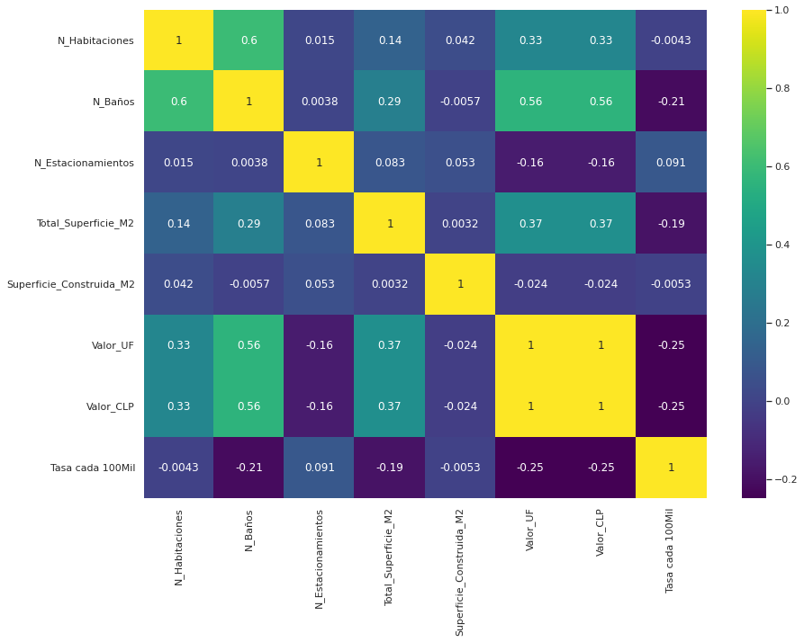

```python
corrData = df_prop_delincuencia_2020.corr()
print("Correlación")
# print(corrData)
sns.set(style="darkgrid")
# heatmap covarianza
plt.figure(figsize=(14, 10))
sns.heatmap(df_prop_delincuencia_2020.corr(), cmap='viridis', annot=True);
```

Se puede apreciar una correlación negativa de -0.25 entre 'Tasa cada 100mil' y el precio(Valor_UF y Valor_CLP), que describe que mientras mayor sea el valor del primero influirá de manera indirectamente proporcional.

### Gráficos

Se hace un filtro de outliers, según 'Superficie_Construida_M2', 'Total_Superficie_M2', 'N_Habitaciones', 'N_Baños' y 'Valor_UF'.

```python
#Filtramos ouliers
df_prop_delincuencia_2020_filter = df_prop_delincuencia_2020[(df_prop_delincuencia_2020["Superficie_Construida_M2"]<750) &
                                                             (df_prop_delincuencia_2020["Total_Superficie_M2"]<10000) &
                                                             (df_prop_delincuencia_2020["N_Habitaciones"]<10) &
                                                             (df_prop_delincuencia_2020["N_Baños"]<10) &
                                                             (df_prop_delincuencia_2020["Valor_UF"]<40000)]
```

A continuación 4 boxplots para mostrar el comportamiento de los datos según algunos pares de variables que nos parecen interesantes.

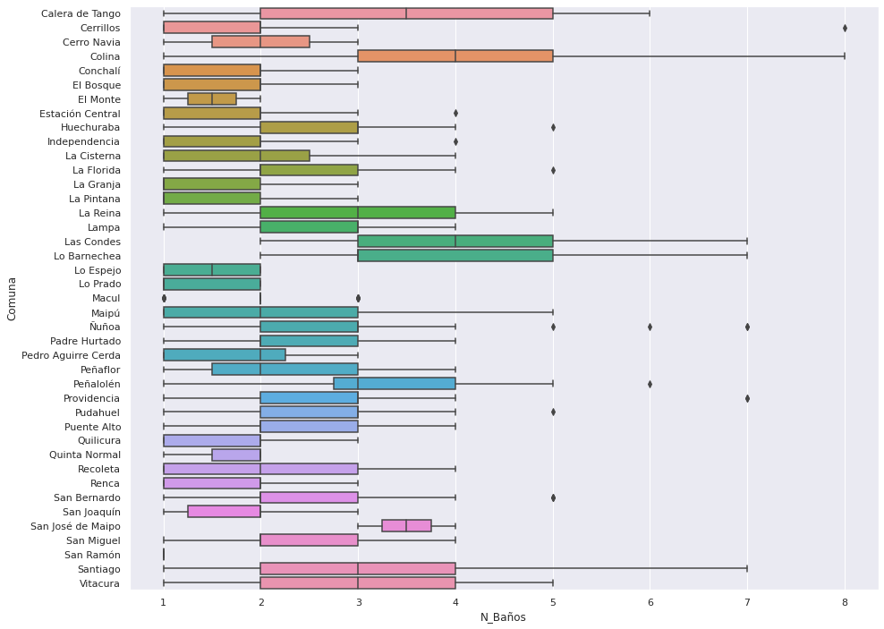

```python
plt.figure(figsize=(15,12))

# Define figure size
sns.set(rc={"figure.figsize":(15, 8)}) #width, height

# Give it to the boxplot
sns.boxplot(y='Comuna', x='N_Baños', data = df_prop_delincuencia_2020_filter)
plt.show();
```

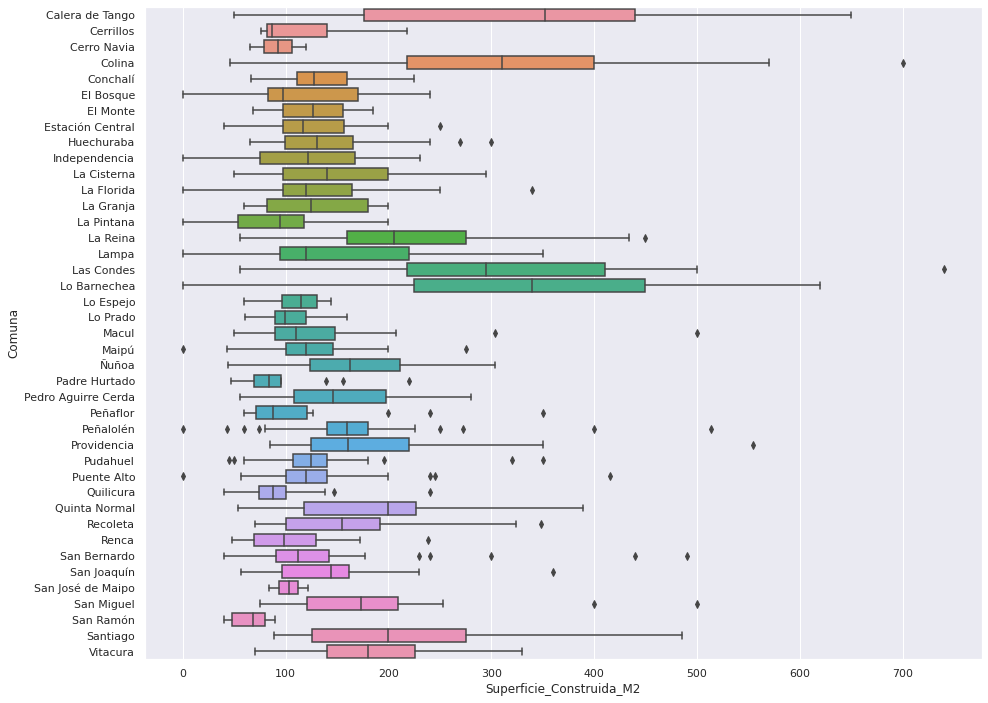

```python
plt.figure(figsize=(15,12))

# Define figure size
sns.set(rc={"figure.figsize":(15, 8)}) #width, height

# Give it to the boxplot
sns.boxplot(y='Comuna', x='Superficie_Construida_M2', data = df_prop_delincuencia_2020_filter)
plt.show();
```

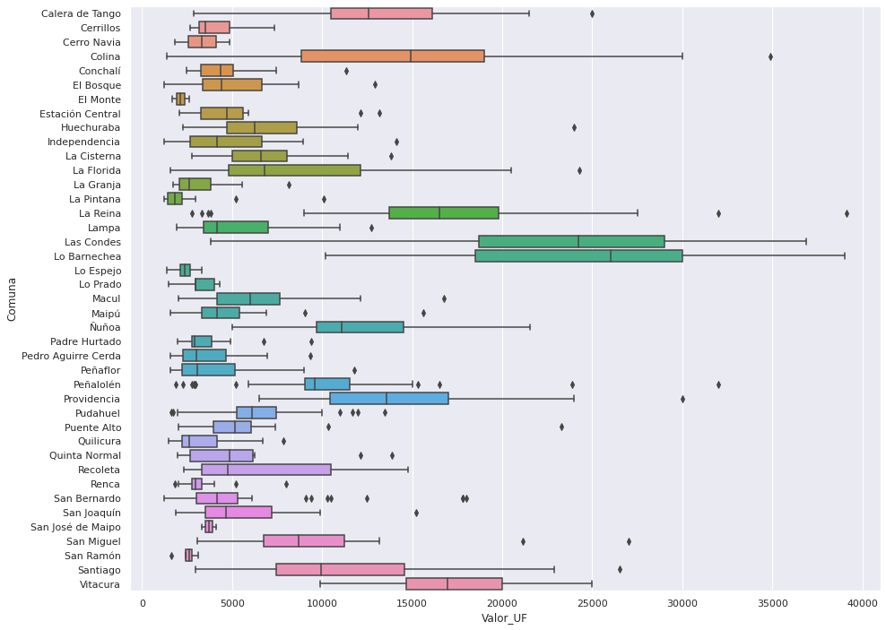

```python
plt.figure(figsize=(15,12))

# Define figure size
sns.set(rc={"figure.figsize":(15, 12)}) #width, height

# Give it to the boxplot
sns.boxplot(y='Comuna', x='Valor_UF', data = df_prop_delincuencia_2020_filter)
plt.show();
```

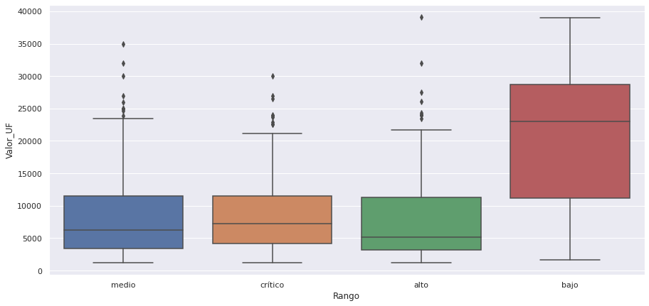

```python
plt.figure(figsize=(15,7))

# Define figure size
sns.set(rc={"figure.figsize":(15, 8)}) #width, height

# Give it to the boxplot
sns.boxplot(x='Rango', y='Valor_UF', data = df_prop_delincuencia_2020_filter)
plt.show();
```

Por último, es interesante agregar una columna con el valor de la razón entre valor_UF y Total_Superficie para el dataset final.

```python
df_prop_delincuencia_2020_filter['ColUF/M2'] = df_prop_delincuencia_2020_filter["Valor_UF"]/df_prop_delincuencia_2020_filter["Total_Superficie_M2"]
```

Se elimina las columnas de 'Quién_Vende' y 'Corredor', dado que no aportan al proyecto ni tampoco las contiene el dataset de viviendas 2022.

```python
df_prop_delincuencia_2020_filter = df_prop_delincuencia_2020_filter.drop(['Quién_Vende', 'Corredor'], axis=1)
```

Head del dataset resultante

```python
df_prop_delincuencia_2020_filter.head(3)
```

|  | Comuna | Link | Tipo_Vivienda | N_Habitaciones | N_Baños | N_Estacionamientos | Total_Superficie_M2 | Superficie_Construida_M2 | Valor_UF | Valor_CLP | Dirección | Tasa cada 100Mil | Rango | ColUF/M2 |
| --- | --- | --- | --- | --- | --- | --- | --- | --- | --- | --- | --- | --- | --- | --- |
| 0 | Calera de Tango | https://chilepropiedades.cl/ver-publicacion/ve... | Casa | 5.0 | 6.0 | 3.0 | 5000.0 | 440.0 | 12200.0 | 351360000 | Calera de Tango, Queilen | 389.1 | medio | 2.440000 |
| 1 | Calera de Tango | https://chilepropiedades.cl/ver-publicacion/ve... | Casa | 6.0 | 6.0 | 6.0 | 5000.0 | 430.0 | 13000.0 | 374400000 | Calera de Tango, Queilen | 389.1 | medio | 2.600000 |
| 2 | Calera de Tango | https://chilepropiedades.cl/ver-publicacion/ve... | Casa | 3.0 | 3.0 | 0.0 | 2027.0 | 140.0 | 10300.0 | 296640000 | Calera de Tango, Avenida calera de tango con... | 389.1 | medio | 5.081401 |

## Data set Propiedades 2022

El siguiente dataset se extrajo del mismo sitio web del data set 2020 (www.chilepropiedades.cl), haciendo un web scrapping para obtener los datos más relevantes.

### Primer análisis

Inicialmente, el dataset contenía 19 columnas y 4017 filas. Los atributos eran: X, Codigo_Aviso, Comuna, Link, Tipo_Vivienda, N_Habitaciones, N_Baños, N_Estacionamientos, Amoblado, Total_Superficie_M2, Superficie_Construida_M2, anoConstruccion, Valor_UF, Valor_CLP, Direccion, tipoPublicacion, Quién_Vende, Corredor, Fecha_Publicacion.

X simplemente indica un indice dentro del dataset. Codigo_Aviso es el codigo que se genera al momento de lanzar el aviso, único en cada tupla. Comuna indica la comuna donde está ubicada la propiedad. Link refercencia a la página donde esta el detalle de la publicación. Tipo_Vivienda indica si es casa o departamento. N_Habitaciones, N_Baños y N_Estacionamientosindica el número que tiene cada propiedad, colocando el valor NA si no contiene. Amoblado indica si está amoblado y o no. Total_Superficie_M2 y Superficie_Construida_M2 indican en metros cuadrados la superficie del inmueble. anoConstruccion indica el año de construcción con el valor vacío si no se tiene esa información. Valor_UF y Valor_CLP indican el valor del inmueble en la medida correspondiente. Direccion indica la calle y comuna donde esta ubicada la propiedad. tipoPublicacion indica si es una casa anteriormente usada o nueva. Quién_Vende y Corredor indican el nombre correspondiente. Por útlimo Fecha_Publicacion indica la fecha en que fue ofertada y publicada la propiedad.

Primero que todo, como existían strings vacíos en la columna `Amoblado`, se cambiaron estos valores por nulo. Después, se utilizó el comando `summary`, para analizar algunas medidas de tendencia central, como el promedio y ver la cantidad de nulos por columna.

```python
#Carga dataset
url_raw_prop_2022 = 'https://raw.githubusercontent.com/ccarrions/Data_Mining_Project/main/dataset_chile_prop_2022.csv'
# dataframe sector
df_prop_2022 = pd.read_csv(url_raw_prop_2022, sep=",", encoding= "utf-8")
df_prop_2022.head(3)
```

|  | Unnamed: 0 | Codigo_Aviso | Comuna | Link | Tipo_Vivienda | N_Habitaciones | N_Baños | N_Estacionamientos | Amoblado | Total_Superficie_M2 | Superficie_Construida_M2 | anoConstruccion | Valor_UF | Valor_CLP | Dirección | tipoPublicacion | Quién_Vende | Corredor | fechaPublicacion |
| --- | --- | --- | --- | --- | --- | --- | --- | --- | --- | --- | --- | --- | --- | --- | --- | --- | --- | --- | --- |
| 0 | 0 | 6031175 | Quinta Normal | https://chilepropiedades.cl/ver-publicacion/ve... | Casa | 3.0 | 3.0 | NaN | No | 750.0 | 457.0 | NaN | 15300.00 | 485622000.0 | Quinta Normal, Salvador Gutierrez con Nuñez de... | Venta Usada | Oliver Propiedades ... | Unne | 02/04/2022 |
| 1 | 1 | 5592922 | Santiago | https://chilepropiedades.cl/ver-publicacion/ve... | Casa | 5.0 | 2.0 | 2.0 | NaN | 147.0 | 159.0 | NaN | 4788.91 | 152000000.0 | Santiago, Avenida El Rosal | Venta Usada | fabian M. | fabian | 07/03/2022 |
| 2 | 2 | 6720221 | Maipú | https://chilepropiedades.cl/ver-publicacion/ve... | Casa | 2.0 | 1.0 | 1.0 | No | 111.0 | 96.0 | NaN | 3056.08 | 97000000.0 | Maipú, El Huaso 2546 Maipú | Venta Usada | Baquedano Consultores ... | Unne | 02/04/2022 |

Cantidad de Filas y columnas iniciales del dataset.

```python
df_prop_2022.shape
```

```
(4017, 19)
```

Se muestra a continuación diversas medidas de tendencia central iniciales de cada columna númerica.

```python
df_prop_2022.describe()
```

|  | Unnamed: 0 | Codigo_Aviso | N_Habitaciones | N_Baños | N_Estacionamientos | Total_Superficie_M2 | Superficie_Construida_M2 | anoConstruccion | Valor_UF | Valor_CLP |
| --- | --- | --- | --- | --- | --- | --- | --- | --- | --- | --- |
| count | 4017.000000 | 4.017000e+03 | 3989.000000 | 3973.000000 | 2808.000000 | 3.962000e+03 | 3.917000e+03 | 535.000000 | 4.016000e+03 | 4.015000e+03 |
| mean | 2008.000000 | 6.108551e+06 | 4.113061 | 2.630758 | 2.443020 | 1.125959e+03 | 7.197231e+02 | 1998.685981 | 1.561284e+05 | 4.956671e+09 |
| std | 1159.752344 | 8.278420e+05 | 3.283420 | 1.618850 | 2.375874 | 2.598785e+04 | 2.605763e+04 | 31.584950 | 5.515248e+06 | 1.750757e+11 |
| min | 0.000000 | 1.007205e+06 | 1.000000 | 1.000000 | 1.000000 | 0.000000e+00 | 0.000000e+00 | 1500.000000 | 1.400000e-01 | 4.430000e+03 |
| 25% | 1004.000000 | 5.874058e+06 | 3.000000 | 2.000000 | 1.000000 | 1.230000e+02 | 9.000000e+01 | 1986.500000 | 3.597500e+03 | 1.141053e+08 |
| 50% | 2008.000000 | 6.377059e+06 | 4.000000 | 2.000000 | 2.000000 | 2.000000e+02 | 1.350000e+02 | 2005.000000 | 6.000000e+03 | 1.904400e+08 |
| 75% | 3012.000000 | 6.675854e+06 | 5.000000 | 3.000000 | 3.000000 | 4.500000e+02 | 2.200000e+02 | 2022.000000 | 1.380000e+04 | 4.380120e+08 |
| max | 4016.000000 | 6.841202e+06 | 175.000000 | 29.000000 | 60.000000 | 1.626000e+06 | 1.626000e+06 | 2022.000000 | 2.500000e+08 | 7.935000e+12 |

```python
#Nulos
df_prop_2022.isna().sum()
```

```
Unnamed: 0                     0
Codigo_Aviso                   0
Comuna                         0
Link                           0
Tipo_Vivienda                  0
N_Habitaciones                28
N_Baños                       44
N_Estacionamientos          1209
Amoblado                     786
Total_Superficie_M2           55
Superficie_Construida_M2     100
anoConstruccion             3482
Valor_UF                       1
Valor_CLP                      2
Dirección                      0
tipoPublicacion                0
Quién_Vende                    0
Corredor                     340
fechaPublicacion               0
dtype: int64
```

```python
#Número de propiedades usadas y no usadas
df_prop_2022["tipoPublicacion"].value_counts()
```

```
Venta Usada    3996
Venta Nueva      21
Name: tipoPublicacion, dtype: int64
```

### Datos Faltantes

Para el precio, se busca maualmente en la web para añadirlo al data (excepción en webscrapping)

```python
# Busqueda Manual
# Instancias Nulas: fila 3719 Valor uf y clp, fila 3763 valor clp
df_prop_2022["Valor_UF"][3719]
df_prop_2022["Valor_CLP"][3719]
df_prop_2022["Valor_CLP"][3763]
```

```
nan
```

```python
#Links
df_prop_2022["Link"][3719]
df_prop_2022["Link"][3763]
```

```
'https://chilepropiedades.cl/ver-publicacion/venta-usada/santiago/casa/chicureo/6536579'
```

```python
#Asignar Valores
df_prop_2022["Valor_UF"][3719] = 16500
df_prop_2022["Valor_CLP"][3719] = 523811310
df_prop_2022["Valor_CLP"][3763] = 313312000
```

Luego, para las columnas numéricas, se cambiaron los valores nulos por el promedio de la columna.

```python
#Promedios
mean_habitaciones = df_prop_2022[df_prop_2022["N_Habitaciones"].notnull()]["N_Habitaciones"].mean()
mean_banos = df_prop_2022[df_prop_2022["N_Baños"].notnull()]["N_Baños"].mean()
mean_supConstruida = df_prop_2022[df_prop_2022["Superficie_Construida_M2"].notnull()]["Superficie_Construida_M2"].mean()
mean_totalSup = df_prop_2022[df_prop_2022["Total_Superficie_M2"].notnull()]["Total_Superficie_M2"].mean()
mean_estacionamientos = df_prop_2022[df_prop_2022["N_Estacionamientos"].notnull()]["N_Estacionamientos"].mean()
```

```python
#Reemplazo de valores nulos
df_prop_2022.loc[df_prop_2022["N_Habitaciones"].isna(), "N_Habitaciones"] = mean_habitaciones
df_prop_2022.loc[df_prop_2022["N_Baños"].isna(), "N_Baños"] = mean_banos
df_prop_2022.loc[df_prop_2022["Superficie_Construida_M2"].isna(), "Superficie_Construida_M2"] = mean_supConstruida
df_prop_2022.loc[df_prop_2022["Total_Superficie_M2"].isna(), "Total_Superficie_M2"] = mean_totalSup
df_prop_2022.loc[df_prop_2022["N_Estacionamientos"].isna(), "N_Estacionamientos"] = mean_estacionamientos
```

### Algunas exploraciones iniciales del dataset

```
Correlación
```

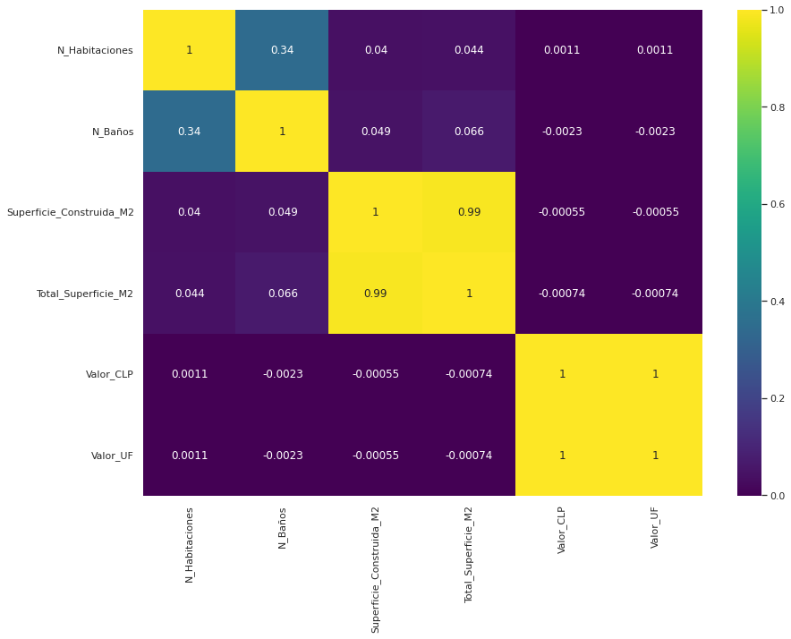

```python
corrData = df_prop_2022[["N_Habitaciones", "N_Baños", "Superficie_Construida_M2", "Total_Superficie_M2", "Valor_CLP", "Valor_UF"]].corr()
print("Correlación")
# print(corrData)
sns.set(style="darkgrid")
# heatmap covarianza
plt.figure(figsize=(14, 10))
sns.heatmap(corrData, cmap='viridis', annot=True);
```

También, existe una correlación, como era de esperar, entre la superficie construida y la superficie total. Como el atributo de la total superficie contiene menos nulos, se dejará esta columna. Y la última gran correlación es entre el precio en CLP y en UF.

Tras haber corrido el comando summary, vemos que en ciertos atributos el minimo y el máximo varían considerablemente. Como en el número de habitaciones, de baños, de estacionamientos. Asimismo en la superficie total y en la superficie construida. Para ver los posibles outliers, agruparemos el dataset por comuna

```python
df_prop_2022.describe()
```

|  | Unnamed: 0 | Codigo_Aviso | N_Habitaciones | N_Baños | N_Estacionamientos | Total_Superficie_M2 | Superficie_Construida_M2 | anoConstruccion | Valor_UF | Valor_CLP |
| --- | --- | --- | --- | --- | --- | --- | --- | --- | --- | --- |
| count | 4017.000000 | 4.017000e+03 | 4017.000000 | 4017.000000 | 4017.000000 | 4.017000e+03 | 4.017000e+03 | 535.000000 | 4.017000e+03 | 4.017000e+03 |
| mean | 2008.000000 | 6.108551e+06 | 4.113061 | 2.630758 | 2.443020 | 1.125959e+03 | 7.197231e+02 | 1998.685981 | 1.560936e+05 | 4.954412e+09 |
| std | 1159.752344 | 8.278420e+05 | 3.271953 | 1.609957 | 1.986313 | 2.580928e+04 | 2.573116e+04 | 31.584950 | 5.514561e+06 | 1.750322e+11 |
| min | 0.000000 | 1.007205e+06 | 1.000000 | 1.000000 | 1.000000 | 0.000000e+00 | 0.000000e+00 | 1500.000000 | 1.400000e-01 | 4.430000e+03 |
| 25% | 1004.000000 | 5.874058e+06 | 3.000000 | 2.000000 | 2.000000 | 1.240000e+02 | 9.000000e+01 | 1986.500000 | 3.600000e+03 | 1.142640e+08 |
| 50% | 2008.000000 | 6.377059e+06 | 4.000000 | 2.000000 | 2.443020 | 2.000000e+02 | 1.390000e+02 | 2005.000000 | 6.000000e+03 | 1.904400e+08 |
| 75% | 3012.000000 | 6.675854e+06 | 5.000000 | 3.000000 | 2.443020 | 4.740000e+02 | 2.320000e+02 | 2022.000000 | 1.380000e+04 | 4.380120e+08 |
| max | 4016.000000 | 6.841202e+06 | 175.000000 | 29.000000 | 60.000000 | 1.626000e+06 | 1.626000e+06 | 2022.000000 | 2.500000e+08 | 7.935000e+12 |

```python
new_df_prop_2022 = df_prop_2022[["Comuna", "N_Habitaciones", "N_Baños", "N_Estacionamientos", "Amoblado", "Total_Superficie_M2", "Valor_UF", "Link"]]
new_df_prop_2022.head(3)
```

|  | Comuna | N_Habitaciones | N_Baños | N_Estacionamientos | Amoblado | Total_Superficie_M2 | Valor_UF | Link |
| --- | --- | --- | --- | --- | --- | --- | --- | --- |
| 0 | Quinta Normal | 3.0 | 3.0 | 2.44302 | No | 750.0 | 15300.00 | https://chilepropiedades.cl/ver-publicacion/ve... |
| 1 | Santiago | 5.0 | 2.0 | 2.00000 | NaN | 147.0 | 4788.91 | https://chilepropiedades.cl/ver-publicacion/ve... |
| 2 | Maipú | 2.0 | 1.0 | 1.00000 | No | 111.0 | 3056.08 | https://chilepropiedades.cl/ver-publicacion/ve... |

### Outliers

Se hacen 4 boxplots para ver y detectar outliers según algunos pares de variables.

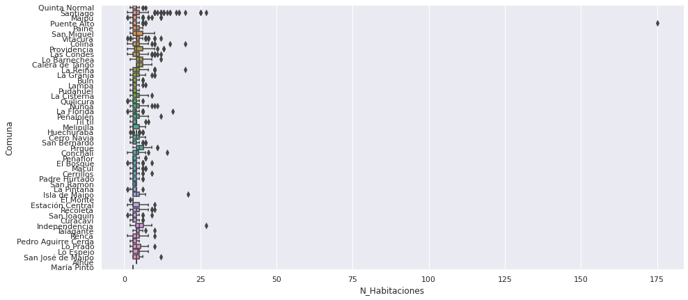

```python
plt.figure(figsize=(15,7))

# Define figure size
sns.set(rc={"figure.figsize":(15, 8)}) #width, height

# Give it to the boxplot
sns.boxplot(y='Comuna', x='N_Habitaciones', data = new_df_prop_2022)
plt.show();
```

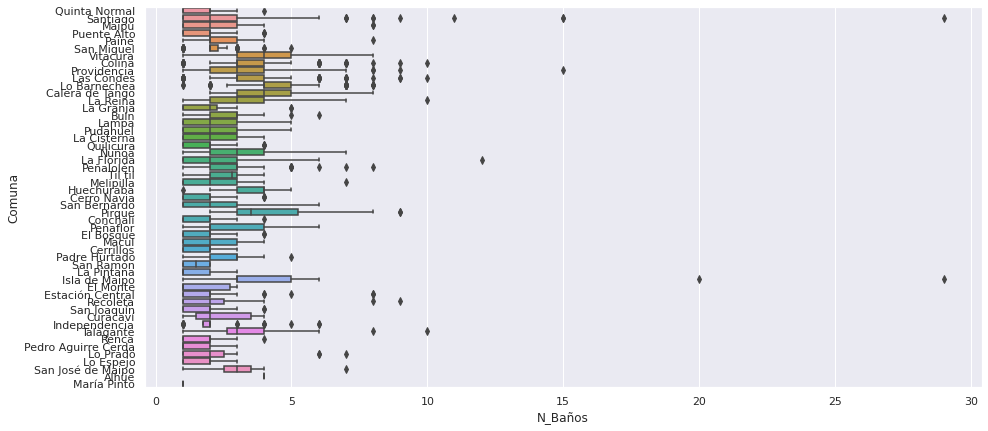

```python
plt.figure(figsize=(15,7))

# Define figure size
sns.set(rc={"figure.figsize":(15, 8)}) #width, height

# Give it to the boxplot
sns.boxplot(y='Comuna', x='N_Baños', data = new_df_prop_2022)
plt.show();
```

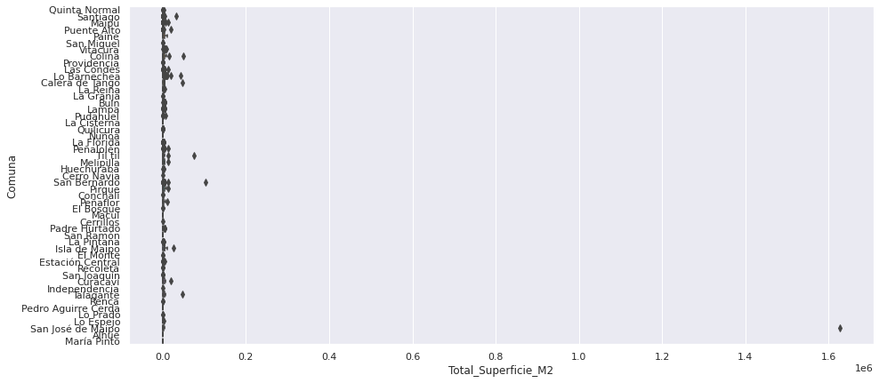

```python
plt.figure(figsize=(15,7))

# Define figure size
sns.set(rc={"figure.figsize":(15, 8)}) #width, height

# Give it to the boxplot
sns.boxplot(y='Comuna', x='Total_Superficie_M2', data = new_df_prop_2022)
plt.show();
```

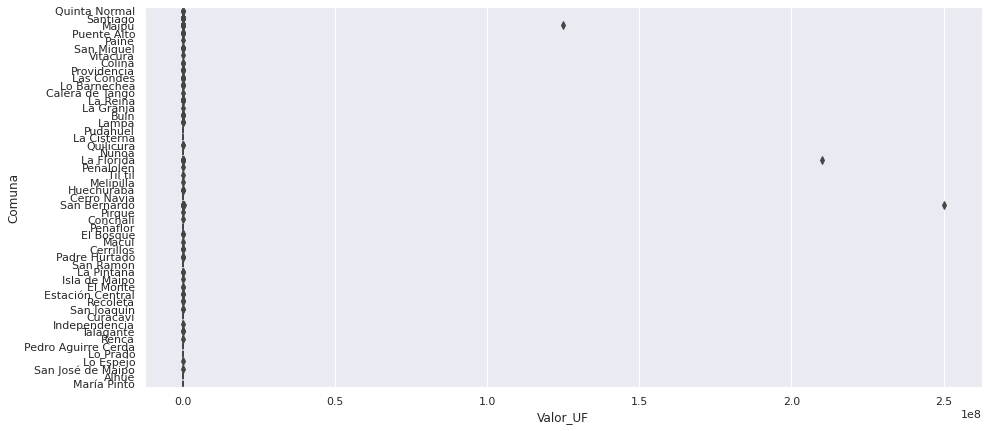

```python
plt.figure(figsize=(15,7))

# Define figure size
sns.set(rc={"figure.figsize":(15, 8)}) #width, height

# Give it to the boxplot
sns.boxplot(y='Comuna', x='Valor_UF', data = new_df_prop_2022)
plt.show();
```

Para N_Habitaciones, existen outliers con valores mayores a 25. Para el número de baños, existen poco valores mayores a 10. Para N_Estacionamientos, lo mismo para valores mayores a 20. Para total superficie, mayores de 250.000. y para Valor_UF, valores mayores a 20000000. Eliminaremos aquellas filas.

Repetimos el proceso otra vez para ajustar los valores.

### Finalmente:

Filtramos outliers según las columnas: Total_Superficie_M2, N_Habitaciones, N_Estacionamientos, N_Baños y Valor_UF.

```python
#Filtramos ouliers
new_df_prop_2022_filter = new_df_prop_2022[(new_df_prop_2022["Total_Superficie_M2"]<15000) &
                                            (new_df_prop_2022["N_Habitaciones"]<10) &
                                            (new_df_prop_2022["N_Estacionamientos"]<8) &
                                            (new_df_prop_2022["N_Baños"]<8) &
                                            (new_df_prop_2022["Valor_UF"]<45000)]
```

Creamos nuevamente los mismos 4 boxplots que se hicieron anteriormente, ahora con los outliers filtrados.

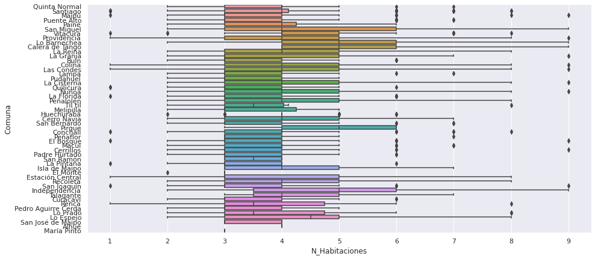

```python
plt.figure(figsize=(15,7))

# Define figure size
sns.set(rc={"figure.figsize":(15, 8)}) #width, height

# Give it to the boxplot
sns.boxplot(y='Comuna', x='N_Habitaciones', data = new_df_prop_2022_filter)
plt.show();
```

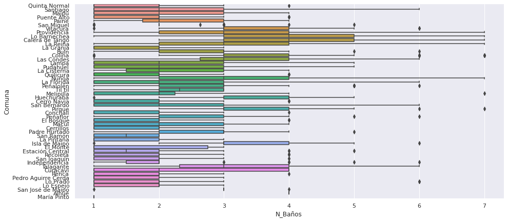

```python
plt.figure(figsize=(15,7))

# Define figure size
sns.set(rc={"figure.figsize":(15, 8)}) #width, height

# Give it to the boxplot
sns.boxplot(y='Comuna', x='N_Baños', data = new_df_prop_2022_filter)
plt.show();
```

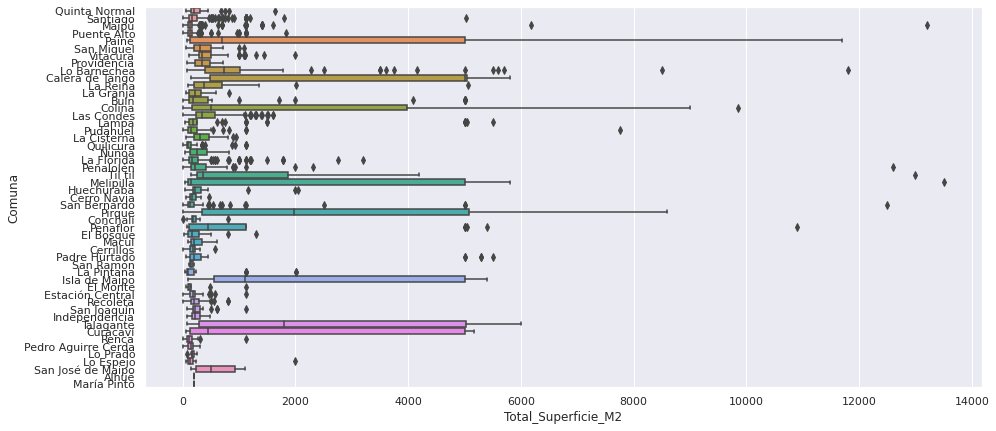

```python
plt.figure(figsize=(15,7))

# Define figure size
sns.set(rc={"figure.figsize":(15, 8)}) #width, height

# Give it to the boxplot
sns.boxplot(y='Comuna', x='Total_Superficie_M2', data = new_df_prop_2022_filter)
plt.show();
```

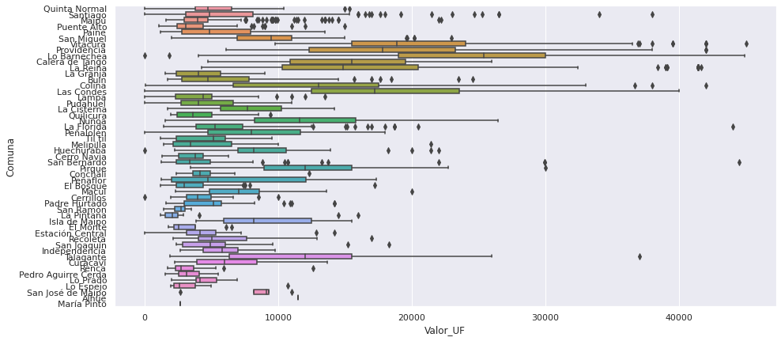

```python
plt.figure(figsize=(15,7))

# Define figure size
sns.set(rc={"figure.figsize":(15, 8)}) #width, height

# Give it to the boxplot
sns.boxplot(y='Comuna', x='Valor_UF', data = new_df_prop_2022_filter)
plt.show();
```

### Finalmente, el data set final:

```python
new_df_prop_2022_filter.head(3)
```

|  | Comuna | N_Habitaciones | N_Baños | N_Estacionamientos | Amoblado | Total_Superficie_M2 | Valor_UF | Link |
| --- | --- | --- | --- | --- | --- | --- | --- | --- |
| 0 | Quinta Normal | 3.0 | 3.0 | 2.44302 | No | 750.0 | 15300.00 | https://chilepropiedades.cl/ver-publicacion/ve... |
| 1 | Santiago | 5.0 | 2.0 | 2.00000 | NaN | 147.0 | 4788.91 | https://chilepropiedades.cl/ver-publicacion/ve... |
| 2 | Maipú | 2.0 | 1.0 | 1.00000 | No | 111.0 | 3056.08 | https://chilepropiedades.cl/ver-publicacion/ve... |

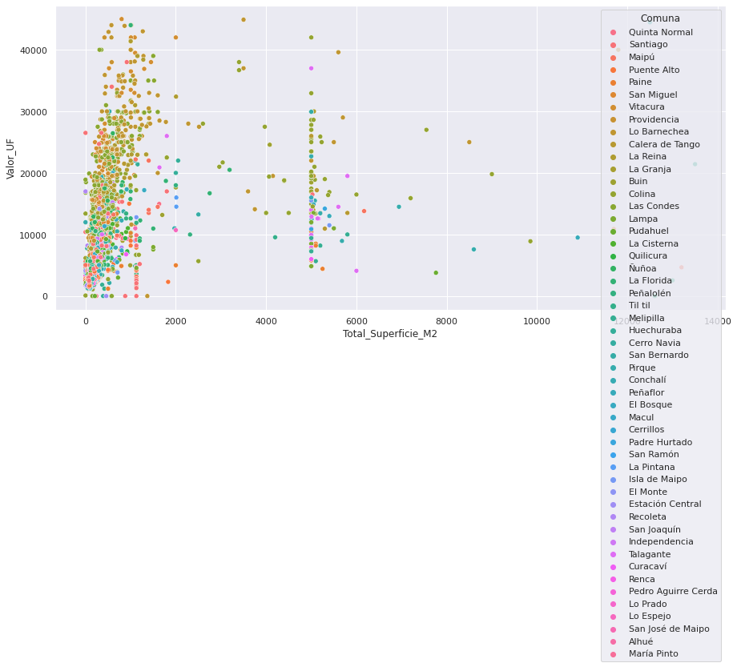

```python
plt.figure(figsize=(15,7))

# Define figure size
sns.set(rc={"figure.figsize":(15, 8)}) #width, height

# Give it to the boxplot
sns.scatterplot(x='Total_Superficie_M2', y='Valor_UF', hue='Comuna', data =new_df_prop_2022_filter)
plt.show();
```

#### Además, es interesante estudiar el valor de metro cuadrado por comuna. Para eso:

```python
new_df_prop_2022_filter["colUF/m2"] = round(new_df_prop_2022_filter["Valor_UF"]/new_df_prop_2022_filter["Total_Superficie_M2"])
```

```python
new_df_prop_2022_filter.head(3)
```

|  | Comuna | N_Habitaciones | N_Baños | N_Estacionamientos | Amoblado | Total_Superficie_M2 | Valor_UF | Link | colUF/m2 |
| --- | --- | --- | --- | --- | --- | --- | --- | --- | --- |
| 0 | Quinta Normal | 3.0 | 3.0 | 2.44302 | No | 750.0 | 15300.00 | https://chilepropiedades.cl/ver-publicacion/ve... | 20.0 |
| 1 | Santiago | 5.0 | 2.0 | 2.00000 | NaN | 147.0 | 4788.91 | https://chilepropiedades.cl/ver-publicacion/ve... | 33.0 |
| 2 | Maipú | 2.0 | 1.0 | 1.00000 | No | 111.0 | 3056.08 | https://chilepropiedades.cl/ver-publicacion/ve... | 28.0 |

### Dataset delincuencia 2022

Se cargan los datos del dataset de delincuencia 2022

```python
#Carga dataset
url_raw_delincuencia_2022 = 'https://raw.githubusercontent.com/ccarrions/Data_Mining_Project/main/Delincuencia2022.csv'
# dataframe sector
df_delincuencia_2022 = pd.read_csv(url_raw_delincuencia_2022, sep=";", encoding= "utf-8")
#Arreglamos nomenclatura comuna Til til
df_delincuencia_2022.loc[df_delincuencia_2022["Comuna"] == "Tiltil", "Comuna"] = "Til til"

df_delincuencia_2022.head(3)
```

|  | Tipo de Información | Comuna | Frecuencia | Tasa cada 100Mil | Rango |
| --- | --- | --- | --- | --- | --- |
| 0 | Casos Policiales | Alhué | 24 | 318,50 | medio |
| 1 | Casos Policiales | Buin | 487 | 435,10 | medio |
| 2 | Casos Policiales | Calera de Tango | 123 | 423,90 | medio |

### Cruze de dataset delincuencia

Se fusiona el dataset de viviendas 2022 con el dataset de delincuencia correspondiente a la fecha, según la comuna de cada tupla del primer dataset. Se selecciona solo las columnas de 'Tasa cada 100Mil' y 'Rango', para agregar a las tablas de vivienda.

```python
df_delincuencia_2022_filter = df_delincuencia_2022[['Comuna', 'Tasa cada 100Mil', 'Rango']]
df_prop_delincuencia_2022 = pd.merge(new_df_prop_2022_filter,df_delincuencia_2022_filter,on='Comuna',how='left')
```

```python
#Datos a numérico
df_prop_delincuencia_2022["Tasa cada 100Mil"] = df_prop_delincuencia_2022["Tasa cada 100Mil"].str.replace(",",".")
df_prop_delincuencia_2022["Tasa cada 100Mil"] = pd.to_numeric(df_prop_delincuencia_2022["Tasa cada 100Mil"])
```

```python
df_prop_delincuencia_2022.describe()
```

|  | N_Habitaciones | N_Baños | N_Estacionamientos | Total_Superficie_M2 | Valor_UF | colUF/m2 | Tasa cada 100Mil |
| --- | --- | --- | --- | --- | --- | --- | --- |
| count | 3799.000000 | 3799.000000 | 3799.000000 | 3799.000000 | 3799.000000 | 3799.0 | 3799.000000 |
| mean | 3.858015 | 2.464491 | 2.228109 | 532.693235 | 9152.262859 | inf | 538.859989 |
| std | 1.279698 | 1.240857 | 1.054047 | 1171.250808 | 8225.819245 | NaN | 254.085003 |
| min | 1.000000 | 1.000000 | 1.000000 | 0.000000 | 0.140000 | 0.0 | 212.000000 |
| 25% | 3.000000 | 2.000000 | 1.000000 | 120.000000 | 3465.660000 | 21.0 | 370.900000 |
| 50% | 4.000000 | 2.000000 | 2.443020 | 200.000000 | 5671.080000 | 30.0 | 465.600000 |
| 75% | 5.000000 | 3.000000 | 2.443020 | 412.500000 | 12500.000000 | 40.0 | 589.100000 |
| max | 9.000000 | 7.000000 | 7.000000 | 13500.000000 | 44990.000000 | inf | 1567.100000 |

Se muestra las medidas de tendencia central luego de juntar el dataset de viviendas de 2022 junto con el de delincuencia del mismo año.

# Pre-procesamiento de datos

#### Datos faltantes

Como se pudo observar en el primer análisis, existían varios datos faltantes en columnas que se consideraban interesantes a estudiar. Para las columnas numéricas, como `N_Habitaciones` o `N_Baños`, se modificaron los valores nulos por el promedio de esa columna.

Para `Valor_UF` y `Valor_CLP`, se buscó manualmente el precio en el link de la casa en venta, ya que eran errores que se produjeron en el web scrapping.

#### Reducción de la dimensionalidad

Tras haber modificado levemente el dataset y haber insertado los valores faltantes, se prosiguió a analizar las columnas y ver cuáles debían quedarse y cuáles se debían eliminar.

Por la cantidad de nulos en el atributo, se decidió eliminar la columna `anoConstruccion` (3482 NA). Si bien el atributo `N_Estacionamientos` también contiene hartos nulos (1209), se decidió dejar por el momento, ya que, en el dataset del 2020 no hay tantos datos faltantes para este atributo, y podría ser un punto de comparación.

También, se pudo observar que la varianza es 0 para `Tipo_Vivienda`, pues todos los datos son del tipo "Casa". Como la varianza es nula, no aportará mayor información, por lo que se procedió a eliminar este atributo.

Si bien `Codigo_Aviso` no aporta ninguna información relevante, se determinó dejarla por si posteriormente se hace otro web scrapping de las propiedades y analizar las casas nuevas o el cambio de los valores para una misma propiedad.

Después de calcular la correlación entre los atributos numéricos, se puede ver que hay una fuerte correlación entre la superficie construida y la superficie total; y entre el precio en CLP y en UF.

Se deja la columna `Superficie_Total_M2` (55 nulos) y se elimina `Superficie_Construida_M2` (100 nulos), ya que esta última contiene más nulos. Luego, se decide dejar la columna del precio en UF, ya que la varianza es un poco menor y los números son más pequeños.

`Codigo_Aviso`, `Comuna`, `N_Habitaciones`, `N_Baños`, `N_Estacionamientos`, `Amoblado`, `TotalSuperficieM2`, `Valor_UF`, `Dirección`, `tipoPublicacion`, `Quién_Vende`,`Corredor`.

Así, el nuevo dataset se diferencia del dataset del 2020, por lo siguiente:

La ausencia de `Valor_CLP`, `Superficie_Construida_M2`, `link` y `Tipo_Vivienda` que si contiene el dataset del 2020, mientras que el nuevo dataset tiene las columnas de `Codigo_Aviso` y `Amoblado`.

# Datasets Delincuencia

Se extraen dos dataSet, desde el sitio web " https://datoscomunales.pazciudadana.cl ", acerca de los indices de delincuencia por comuna en la región de Santiago, cada uno de estos referenciando un periodo de tiempo diferente. El primero, indica los datos recopilados en el segundo trimestre del año 2020, y el segundo durante el último trimestre del año 2021.

Cada uno muestra la cantidad de casos policiales que ocurrieron en cada comuna de Santiago. Además muestra la cantidad que hubieron cada 100 mil habitantes, junto con una clasificación con respecto a la seguridad en cada comuna.

Estos cuentan con 5 columnas y 52 filas correspondientes a las tuplas. Entre las columnas de atributos tenemos: Tipo de información, Comuna, Frecuencia, Tasa cada 100mil, Rango. Dado que el tipo de información siempre tiene como valor "Casos Policiales", se elimina. Debido a lo simple que son los 2 dataSet no se realizan más prepocesamientos.

Se realizan unas exploraciones básicas del dataSet. Descritas a continuación:

Segundo trimestre 2020:

```python
df_delincuencia_2020.describe()
```

|  | Frecuencia |
| --- | --- |
| count | 52.000000 |
| mean | 716.826923 |
| std | 640.217265 |
| min | 20.000000 |
| 25% | 305.000000 |
| 50% | 600.500000 |
| 75% | 848.500000 |
| max | 3250.000000 |

Tercer Trimestre 2021:

```python
df_delincuencia_2022.describe()
```

|  | Frecuencia |
| --- | --- |
| count | 52.000000 |
| mean | 886.230769 |
| std | 983.208127 |
| min | 24.000000 |
| 25% | 321.250000 |
| 50% | 635.000000 |
| 75% | 1044.500000 |
| max | 6120.000000 |

Se investigan las el tres de comunas con más tasa de delincuencia en cada DataSet, y se presentan a continuación.

Segundo trimestre 2020: En primer lugar Recoleta (771 casos por 100mil habitantes), segundo lugar La Cisterna (770 casos por 100mil habitantes) y tercer lugar San Miguel (733 casos).

Tercer Trimestre 2021: En primer lugar Providencia (1567 casos por 100mil habitantes), segundo lugar Santiago Centro (1183 casos por 100mil habitantes) y tercer lugar Recoleta (962 casos).

# Preguntas y Problemas

En un comienzo, el objetivo de la investigación era analizar los precios de la vivienda pre y post pandemia COVID-19. Sin embargo, el dataset más antiguo corresponde a las viviendas publicadas hasta Mayo del 2020, cuya fecha se ubica a inicios de la pandemia. Por lo que se decidió abordar otro problema: predecir el precio de las casas. Para esto, se utilizó el dataset de viviendas del 2020, del 2022 y otro dataset sobre la delincuencia por comuna en la región metropolitana.

Dada la exploración mostrada en el Item anterior, y dada la motivación del proyecto, se comenzó a analizar las variables a modo de generar un modelo predictivo del precio de las viviendas.

En primer lugar, se analizó qué variables, o combinación de estas, tienen una correlación más importante con el precio de las viviendas. La primera hipótesis planteada es que **el precio puede estar fuertemente relacionado con la comuna en donde se encuentra la vivienda**, y junto a esto, su tasa de delincuencia.

También, pueden existir factores externos que no sean medibles y que puedan afectar el modelo predictivo, como las relaciones entre vecinos del barrio o la estética del vecindario. Como estas variables no son cuantificables, simplemente, no se analizarán. Además, existen otras variables externas como la situación económica actual del país y la pandemia COVID-19 que afectan al precio de la vivienda. ¿Será la pandemia y la crisis económica global un factor a influir en un modelo de predicción pre-pandémico? ¿Existe alguna variable que explique o considere estos efectos que pueda ser agregado a este modelo y adaptar el pasado al presente?

Luego de este primer análisis exploratorio, surgen otras preguntas como ¿qué otras variables pueden influir en el precio de una vivienda? De esta forma, la segunda hipótesis planteada es que **el acceso al transporte público influye en el precio de una casa**. A lo cual, surge el problema de que no se tiene información muy precisa acerca de la ubicación exacta de las viviendas, por lo que verificar el acceso o la cercanía a la locomoción no será muy preciso.

# Contribuciones Hito 1

Asunción Gómez estuvo a cargo de la exploración de datos del dataset Chile Propiedades 2022 junto a la redacción de esa sección del informe. Cristobal Ardiles se encargó de la exploración del dataset Chile Propiedades Mayo 2020 junto con la redacción de esa sección del informe. Cristian Carrión estuvo a cargo de la redacción general del informe, en específico, introducción, preguntas y problemas. Simón Lourido estuvo a cargo de la exploración del dataset de Boston para propósitos de estudio, realizar la presentación y complementear la sección de preguntas y problemas del informe. Roberto Maldonado se encargó de la busqueda del dataset de delincuencia y estudio sobre el impacto de delincuencia, junto con la redacción de esa sección del informe.

# HITO 2

## Introducción

Después de la exploración de datos inicial, se obtuvieron 2 datasets finales: uno sobre las viviendas y delincuencia del año 2020 y otro del año 2022. Se definió como objetivo de este proyecto poder predecir el precio de las viviendas dados ciertos atributos como el número de metros cuadrados, la comuna, etc.

Tras analizar las variables de los datasets finales, cada una de las variables numéricas no tenía una fuerte correlación con el precio. Además, viendo la pregunta sobre qué otras variables pueden influir en el precio de la vivienda, se comenzó a indagar más sobre la geografía y características de la región metropolitana.

De esta forma, se concluyó que faltaban otros atributos, que pueden influir en el precio de una casa, como la cercanía a un metro, a un establecimiento de salud, las áreas verdes de una comuna, etc.

## Exploración de datos

Se pre-procesaron los datasets nuevamente, eliminando aquellas variables que no serían de utilidad como la frecuencia de delincuencia, corredor, quien_vende, entre otras.

De la literatura, [Larraín y Tiznado-Aitken (2021)](https://www.scielo.cl/scielo.php?pid=S0717-50512021000200142&script=sci_arttext), [Fuentes y Pezoa (2018)](https://scielo.conicyt.cl/scielo.php?pid=S0718-34022018000200131&script=sci_arttext&tlng=p) y [James et al. (2021)](https://hastie.su.domains/ISLR2/ISLRv2_website.pdf), se pudo observar que existían otras variables que podían caracterizar sectores de la región metropolitana como [las zonas de la ciudad que tienen buena accesibilidad a establecimientos de educación pública gratuita de calidad mediante transporte público](https://www.scielo.cl/img/revistas/ru/n45//0717-5051-ru-45-00142-fig1.png) o [la calidad del entorno urbano](https://www.scielo.cl/img/revistas/ru/n45//0717-5051-ru-45-00142-fig4.png).

Se decidió agregar información sobre la cercanía a ciertos establecimientos para cada vivienda. Para esto, se obtuvieron diferentes datasets mediante webscrapping y a través del sitio web de [Observatorios de Ciudades UC](https://ideocuc-ocuc.hub.arcgis.com). En estos datasets se encuentran los establecimientos junto a sus direcciones y otras variables. Luego de obtener los datsets, se pre-procesaron para dejar solo las variables interesantes para la problemática.

Por ejemplo, en este dataset se encuentra el equipamiento cultural de la región metropolitana, agrupando teatros, bibliotecas, museos, entre otros.

```python
import pandas as pd
# equipamiento cultural RM
url_equi = "https://raw.githubusercontent.com/asugomez/DM_project/main/csv/new%20variables/Equipamiento_Cultural_RM.csv"
df_equip_cult = pd.read_csv(url_equi, sep=",")
df_equip_cult = df_equip_cult[["direccion", "comuna"]] #"tipo"
df_equip_cult.head() #df_equip_cult.tipo.unique(
```

|  | direccion | comuna |
| --- | --- | --- |
| 0 | 650 ESMERALDA | SANTIAGO |
| 1 | 257 CUETO | SANTIAGO |
| 2 | 1301 BALMACEDA | SANTIAGO |
| 3 | 509 JOSE MIGUEL CLARO | PROVIDENCIA |
| 4 | 1531 MARIO KREUTZBERGER | SANTIAGO |

De esta forma, se obtuvieron los siguientes datasets:

- Equipamiento cultural en la RM (teatro, museo, cine, centro cultural, etc)
- Estaciones de metros en la RM
- Establecimientos educacionales pre básicos
- Establecimientos educacionales
- Clínicas
- Establecimientos de salud (consultorio general, servicio de atención primaria de urgencias, etc).
- Red seguridad (carabineros, investigaciones y bomberos).
- Localización riesgos geofísicos
- Ferias libres y persas
- Supermercados

Tras obtener los datasets, y gracias a la librería geopy de python, se pudo calcular la distancia más cercana a cada uno de estos establecimientos. Para las áreas verdes, no se pudo obtener las direcciones exactas, pero sí el número de metros cuadrados por comuna. Sin embargo, solo se encontró data de 34 comunas, por lo que se decidió dejar afuera esta variable. Asimismo fue el caso para la mayoría de los datasets encontrados, en donde existían datos para una treintena de comunas solamente.

```python
import pandas as pd
url_av_1 = "https://raw.githubusercontent.com/cristobal-ardiles/DM/main/av_1.csv"
df_av_1 = pd.read_csv(url_av_1, sep=",")
df_av_1.head(3)
```

|  | comuna | area_m2 |
| --- | --- | --- |
| 0 | VITACURA | 4580932.874 |
| 1 | RECOLETA | 2931406.341 |
| 2 | MAIPU | 2386040.415 |

```python
df_equip_cult.comuna.unique() # 32
```

```
array(['SANTIAGO', 'PROVIDENCIA', 'RECOLETA', 'LA FLORIDA', 'PUDAHUEL',
       'ESTACION CENTRAL', 'LAS CONDES', 'HUECHURABA',
       'PEDRO AGUIRRE CERDA', 'RENCA', 'CERRILLOS', 'LA REINA',
       'LO BARNECHEA', 'MAIPU', 'SAN MIGUEL', 'VITACURA', 'PUENTE ALTO',
       'CERRO NAVIA', 'NUNOA', 'LO PRADO', 'PENALOLEN', 'LA CISTERNA',
       'SAN RAMON', 'CONCHALI', 'LA GRANJA', 'EL BOSQUE', 'QUILICURA',
       'SAN JOAQUIN', 'SAN BERNARDO', 'LO ESPEJO', 'LA PINTANA',
       'INDEPENDENCIA'], dtype=object)
```

Por esta razón, para este hito se decidió no tener en consideración aquellas variables en donde solo se tuvieran datos para estas comunas. Sin embargo, para el siguiente hito, se propone estudiar la reducción del problema a predecir el precio de las viviendas de estas comunas solamente y así, poder agregar los nuevos datasets estudiados. El trade-off de hacer esto es que se pierden 1327 filas de viviendas, quedando un dataset con 2472 filas.

```python
comunas_new_var = df_equip_cult.comuna.str.lower().unique()

viviendas_sector_acotado = new_df_prop_2022_filter[new_df_prop_2022_filter["Comuna"].str.lower().isin(comunas_new_var)]
len(viviendas_sector_acotado) # 2472
```

```
2472
```

Finalmente, se añadieron a ambos datasets dos nuevas columnas con la información sobre la distancia al metro y al supermercado más cercano.

Es importante mencionar que el objetivo del proyecto es predecir el precio de las viviendas dados ciertos atributos, por lo que, también se puede abordar este problema, haciendo un análisis a cada variable y analizando cuál tiene mayor relevancia en el precio final de la vivienda. ¿Es una casa más cara si está más cercana a un metro? ¿Es más barata si la comuna tiene un mayor rango delictual? Son alguna de las preguntas que se intentarán responder.

## Exploración Dataset Propiedades 2022 con metros y supermercados

A continuación se realiza una exploración del nuevo dataset y se eliminan outliers de casos donde la librería geopy calculó mal las direcciones resultando en distancias erróneas.

```python
df_prop_ext_2022 = pd.read_csv('https://raw.githubusercontent.com/ccarrions/Data_Mining_Project/main/df_prop_delinc_metro_super_2022.csv', sep=",", encoding= "utf-8", index_col=0)
df_prop_ext_2022.head(3)
```

|  | id | Comuna | N_Habitaciones | N_Baños | N_Estacionamientos | Amoblado | Total_Superficie_M2 | Valor_UF | Link | colUF/m2 | Tasa cada 100Mil | Rango | closest_metro | dist_closest_metro | closest_super | closest_super_dist |
| --- | --- | --- | --- | --- | --- | --- | --- | --- | --- | --- | --- | --- | --- | --- | --- | --- |
| 0 | 1 | Quinta Normal | 3.0 | 3.0 | 2.44302 | No | 750.0 | 15300.00 | https://chilepropiedades.cl/ver-publicacion/ve... | 20.0 | 745.1 | alto | GRUTA DE LOURDES | 1.358454 | San Pablo | 1.319246 |
| 1 | 2 | Santiago | 5.0 | 2.0 | 2.00000 | NaN | 147.0 | 4788.91 | https://chilepropiedades.cl/ver-publicacion/ve... | 33.0 | 1183.1 | crítico | SANTIAGO BUERAS | 1.857504 | La Farfana | 0.000000 |
| 2 | 3 | Maipú | 2.0 | 1.0 | 1.00000 | No | 111.0 | 3056.08 | https://chilepropiedades.cl/ver-publicacion/ve... | 28.0 | 370.9 | medio | PLAZA DE MAIPU | 0.166838 | Lider | 1.143968 |

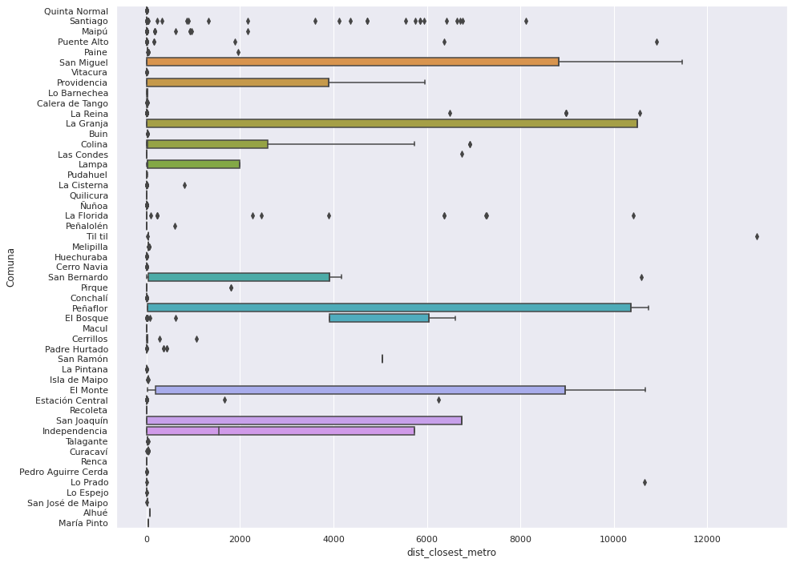

```python
# revisamos outliers
plt.figure(figsize=(15,12))

# Define figure size
sns.set(rc={"figure.figsize":(15, 8)}) #width, height

# Give it to the boxplot
sns.boxplot(y='Comuna', x='dist_closest_metro', data = df_prop_ext_2022)
plt.show();
```

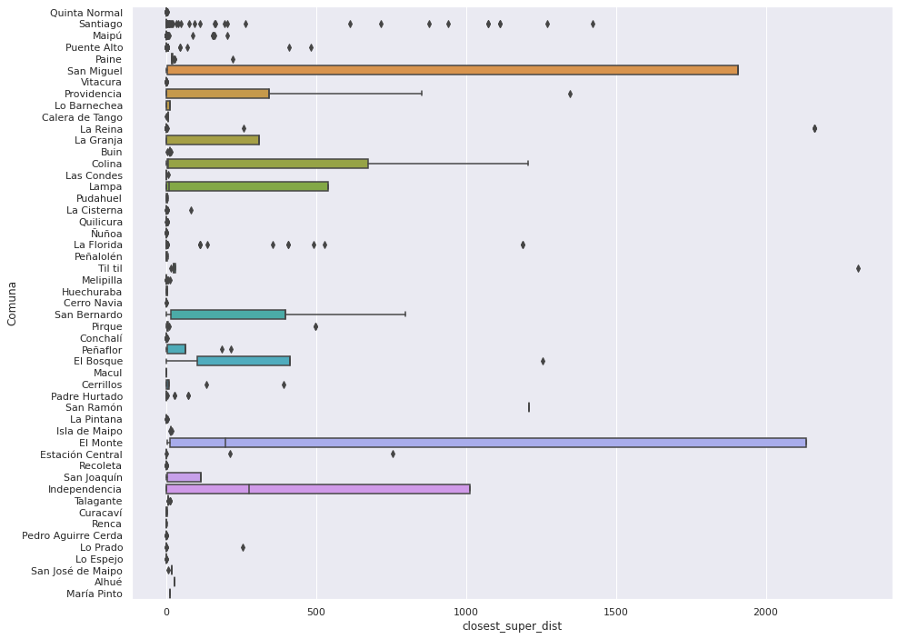

```python
plt.figure(figsize=(15,12))

# Define figure size
sns.set(rc={"figure.figsize":(15, 8)}) #width, height

# Give it to the boxplot
sns.boxplot(y='Comuna', x='closest_super_dist', data = df_prop_ext_2022)
plt.show();
```

```python
df_prop_ext_filter_2022 = df_prop_ext_2022[(df_prop_ext_2022["dist_closest_metro"]<10) &
                                            (df_prop_ext_2022["closest_super_dist"]<8)]

df_prop_ext_filter_2022 = df_prop_ext_filter_2022.drop(['Amoblado','Link','colUF/m2','Rango', "closest_metro", "closest_super"],axis = 1)
```

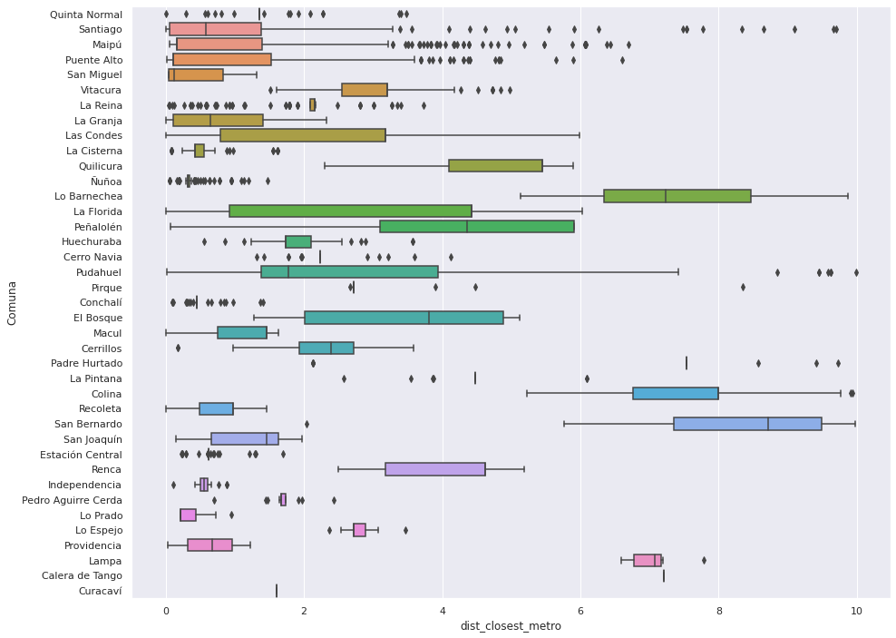

```python
plt.figure(figsize=(15,12))

# Define figure size
sns.set(rc={"figure.figsize":(15, 8)}) #width, height

# Give it to the boxplot
sns.boxplot(y='Comuna', x='dist_closest_metro', data = df_prop_ext_filter_2022)
plt.show();
```

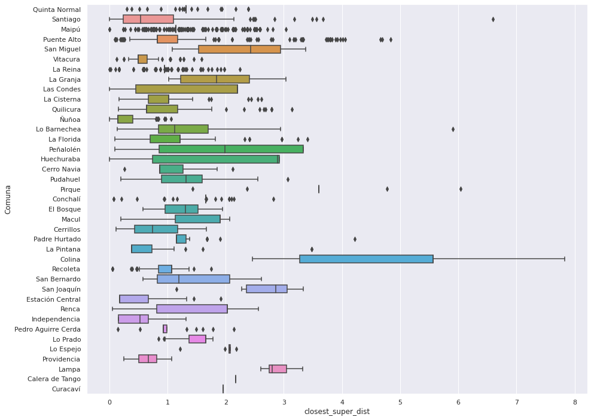

```python
plt.figure(figsize=(15,12))

# Define figure size
sns.set(rc={"figure.figsize":(15, 8)}) #width, height

# Give it to the boxplot
sns.boxplot(y='Comuna', x='closest_super_dist', data = df_prop_ext_filter_2022)
plt.show();
```

```
Correlación
```

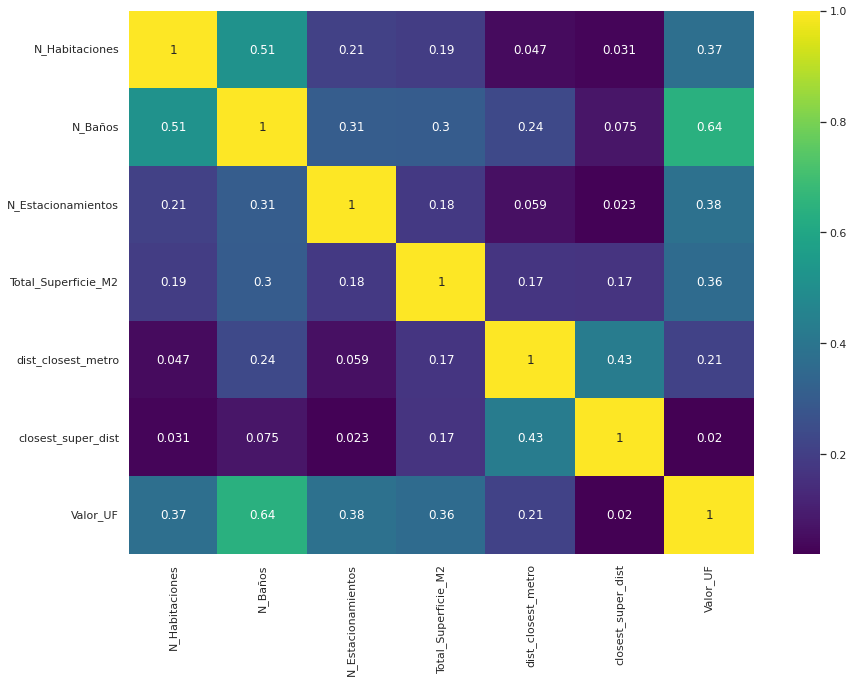

```python
corrData = df_prop_ext_filter_2022[["N_Habitaciones", "N_Baños", "N_Estacionamientos", "Total_Superficie_M2", "dist_closest_metro", "closest_super_dist", "Valor_UF"]].corr()
print("Correlación")
# print(corrData)
sns.set(style="darkgrid")
# heatmap covarianza
plt.figure(figsize=(14, 10))
sns.heatmap(corrData, cmap='viridis', annot=True);
```

Dataset final:

```python
df_prop_ext_filter_2022.head(3)
```

|  | id | Comuna | N_Habitaciones | N_Baños | N_Estacionamientos | Total_Superficie_M2 | Valor_UF | Tasa cada 100Mil | dist_closest_metro | closest_super_dist |
| --- | --- | --- | --- | --- | --- | --- | --- | --- | --- | --- |
| 0 | 1 | Quinta Normal | 3.0 | 3.0 | 2.44302 | 750.0 | 15300.00 | 745.1 | 1.358454 | 1.319246 |
| 1 | 2 | Santiago | 5.0 | 2.0 | 2.00000 | 147.0 | 4788.91 | 1183.1 | 1.857504 | 0.000000 |
| 2 | 3 | Maipú | 2.0 | 1.0 | 1.00000 | 111.0 | 3056.08 | 370.9 | 0.166838 | 1.143968 |

## Propuestas metodológicas experimentales

Dado que las preguntas planteadas en el hito 1 hacen referencia a qué tanto influye una variable en el precio final de la vivienda, y junto con seguir la línea del objetivo del proyecto, se plantean diversas técnicas como métodologías para responder y buscar un camino para resolver las preguntas y problematicas.

### PCA

Para responder la pregunta principal del hito 1, qué variables o combinación de estas afectan con mayor impacto al precio de las viviendas, se propone usar un algoritmo basado en PCA (Análisis de componentes principales), para trabajar los datos y su alta dimensionalidad, y así proyectarlos sobre un espacio de dimensionalidad menor. Esto dado que este tipo de análisis de datos es muy útil para poder relacionar variables entre ellas y entender cómo están relacionadas, reduciendo lo máximo posible y incluso para poder representarlas de manera gráfica.

Dependiendo de los resultados obtenidos y la efectividad del algoritmo, también se deja planteado combinarlo con otras técnicas como clustering para encontrar clusters en los datos y así determinar patrones. Técnicas como K-Means son interesantes a considerar dado que los datos son en la mayoría discretos y categóricos por lo que se piensa que van a ver agrupaciones de estos.

### Clasificadores y Regresiones

Se propone utilizar un algortimo clasificador básado en regresiones, como método para lograr el objetivo principal del proyecto, predecir el precio de las viviendas con respecto a algunas variables dadas.

Para esto se hará un prepocesamiento previo de los dataset para adecuadarlo a las necesidades del algoritmo. Lo anterior incluirá, hacer una conversión de las varibles categóricas a númericas, con un algoritmo de hash para luego poder recuperar los valores iniciales. Se pretendé particionar cada uno de los 2 dataset en tres partes para entrenar los algoritmos con una fracción de estos y así tener otra parte para realizar testeos. Se decide usar Holdout para evaluar el desempeño de los modelos.

\ Se tienen 2 opciones en cuenta para realizar este algoritmo basado en 2 técnicas, Regresión Lineal y Random Forest.

\

#### Regresión Lineal

Se considera Regresión Lineal, dado que es uno de los métodos más simples para aplicar, y es uno de los métodos que se aplican en el estudio de dataset de viviendas de Boston. Se usará una función de pérdida para entrenar el modelo.

#### Random Forest

Por otro lado se considera Random Forest, que es un modelo que combina arboles predictores con vectores aleatorios, dado que es uno de los algoritmos de aprendizaje más certeros que hay disponible, da estimaciones de qué variables son importantes en la clasificación y funciona bien con gran cantidad de variables. Esto dado que los arboles pueden registrar estructuras de interacción compleja en los datos y tienen baja parcialidad.

## Resultado preliminar

Se decidió implementar dos de estas tres técnicas: regresión lineal y random forest.

### Regresión lineal

```python
%load_ext rpy2.ipython
```

```python
df_prop_ext_filter_2022.to_csv('BaseDatosMineria')
```

```python
%%R
library(dplyr)
casa_usadas <- read.csv('BaseDatosMineria')
#Vemos cantidad de NA en la columna de N_Estacionamientos
sum(is.na(casa_usadas$N_Estacionamientos))
#Vemos que la cantidad es minima por lo que procedemos con dropear aquellas filas (No aportan y no es posible estimarles un resultado)
casa_usadas <- casa_usadas[!is.na(casa_usadas$N_Estacionamientos),]

#Cambiamos los No por 0 en numero de estacionamientos (Si no posee, tiene 0)
casa_usadas <- casa_usadas %>%
  mutate(N_Estacionamientos = ifelse(N_Estacionamientos == "No", 0, N_Estacionamientos))

reg1 <- lm(Valor_UF ~ N_Habitaciones+N_Baños+N_Estacionamientos+Total_Superficie_M2+Tasa.cada.100Mil+dist_closest_metro+closest_super_dist, data = casa_usadas)
summary(reg1)
```

```
Call:
lm(formula = Valor_UF ~ N_Habitaciones + N_Baños + N_Estacionamientos +
    Total_Superficie_M2 + Tasa.cada.100Mil + dist_closest_metro +
    closest_super_dist, data = casa_usadas)

Residuals:
   Min     1Q Median     3Q    Max
-35799  -3122   -778   1874  35617

Coefficients:
                      Estimate Std. Error t value Pr(>|t|)
(Intercept)         -4431.8045   493.6418  -8.978  < 2e-16 ***
N_Habitaciones        258.8220   101.7495   2.544   0.0110 *
N_Baños              3372.6308   115.7014  29.149  < 2e-16 ***
N_Estacionamientos   1396.8409   108.7363  12.846  < 2e-16 ***
Total_Superficie_M2     2.1052     0.1842  11.430  < 2e-16 ***
Tasa.cada.100Mil        1.1830     0.4675   2.531   0.0114 *
dist_closest_metro    345.1947    56.0772   6.156 8.56e-10 ***
closest_super_dist   -757.3992   136.2832  -5.558 3.00e-08 ***
---
Signif. codes:  0 ‘***’ 0.001 ‘**’ 0.01 ‘*’ 0.05 ‘.’ 0.1 ‘ ’ 1

Residual standard error: 5692 on 2764 degrees of freedom
Multiple R-squared:  0.4875,	Adjusted R-squared:  0.4862
F-statistic: 375.6 on 7 and 2764 DF,  p-value: < 2.2e-16
```

A pesar de no tener un R cuadrado ajustado alto (0.4862), si se logra apreciar que la significancia estadistica de los coeficientes que acompañan a las variables si son significativos, en su gran mayoria al 1% de significancia y para los coeficientes de tasa y numero de habitaciones al 10%, por lo que las variables escogidas si son representativas de nuestro modelo. Sin embargo, al tener un R cuadrado ajustado de tan solo un 0.48, se podria esperar que parte de la explicacion de los precios en valor UF se deben estar explicando por variables que no fueron agregadas al modelo o simplemente por variables que no son observables. Además se logra apreciar que la distancia a los supermercados afectan de manera negativa al precio de la casa, lo que podria llevar a pensar que la simplicidad del modelo podria estar afectando a la prediccion del precio.

### Random Forest

```python
from sklearn.model_selection import train_test_split
```

```python
#Definimos los predictores y la variable objetivo
df_numeric = df_prop_ext_filter_2022.copy().drop(["id", "Comuna", "Valor_UF"], axis=1)
df_numeric.head(3)

target = list(df_prop_ext_filter_2022["Valor_UF"])

X_train, X_test, y_train, y_test = train_test_split(df_numeric, target, test_size=.33, random_state=37)
```

```python
# Fitting Random Forest Regression to the dataset
# import the regressor
from sklearn.ensemble import RandomForestRegressor

# create regressor object
regressor = RandomForestRegressor(n_estimators = 100, random_state = 0)

# fit the regressor with x and y data
regressor.fit(X_train, y_train)
y_pred = regressor.predict(X_test)
```

```python
print(y_pred[0:10])
print(y_test[0:10])
```

```
[ 4888.87416  5531.4816   3365.6391  25632.771   14075.4795   2200.4261
  4398.7226   4787.5357  13768.2895   4350.2142 ]
[5671.08, 4883.43, 2205.42, 27500.0, 10500.0, 2500.0, 2804.03, 4410.84, 14500.0, 3938.25]
```

## Decision Tree

Ejecutamos un árbol de decisión para analizar las variables que utiliza para predecir el precio de la propiedad

```python
from sklearn import tree
from sklearn.metrics import classification_report
import matplotlib.pyplot as plt

tree_regressor = tree.DecisionTreeRegressor(max_depth=5)
tree_regressor.fit(X_train, y_train)
y_pred_1 = tree_regressor.predict(X_test)

plt.figure(figsize = (200,50))
tree.plot_tree(tree_regressor, fontsize=20, feature_names = list(df_numeric.columns))
#plt.savefig("dt1.svg", format="svg")
plt.show()
```

[figure not shown]

Del análisis del árbol podemos observar que las variables "Total Superficie Construida", "N Baños" y "Distancia closest metro" son las más importantes para predecir el precio de una propiedad. Sin embargo, dicha conclusión debe ser respaldada luego de analizar el error del algoritmo, lo que queda pendiente para el hito 3.

# Contribuciones

Cristóbal fue el encargado de encontrar y pre-procesar los datasets de supermercados y de áreas verdes. Luego, de crear el algoritmo de Random-Forest junto a Simón. Simón, por su parte, se encargó de re-pre-procesar los datos del hito 1, procesar las variables categóricas y de la regresión lineal.

Cristián se encargó de encontrar el dataset de metros de la región metropolitana y de crear la función que calculá la distancia mínima entre las viviendas y los establecimientos.

Roberto fue el responsable de agregar una pequeña descripción a todos los gráficos del hito 1 y de eliminar aquellos poco relevantes. Luego se encargó de indagar más sobre cada técnica de minería de datos utilizada para ver porqué se utilizaría cada una. Finalmente, redactó la propuesta metodológica.

Asunción se encargó de buscar en la literatura qué variables podrían ser útiles en el problema del proyecto. Luego, fue la responsable de encontrar y pre-procesar los datasets de las nuevas variables que se agregaron como riesgo geofísico, clinicas, establecimientos de salud, etc. Además, mejoró la redacción del hito 1 y redactó la primera parte del hito 2.